# Visualizations and reports

Jure Demsar and Gregor Pirs

31/1/2019

[figure not shown]

# Exercise 1

Read the player_wage.csv data (source: https://www.kaggle.com/aishjun/nba-salaries-prediction-in-20172018-season#2017-18_NBA_salary.csv) and save it as a tibble. The observations in the data set are NBA players, their information (statistics, nationality,…), and their wages. For a glossary of NBA terms, see https://www.basketball-reference.com/about/glossary.html.

Peform following tasks:

1. Create a tibble with only Slovenian players.
2. Create a tibble with all USA players who play for Golden State Warriors (GWS).
3. Arrange Players first by age, then by salary, both descending.
4. Create a tibble with columns name, country, draft number, age, and team.
5. Add a new variable to the data frame, minutes per game (MPG).
6. Create a tibble with average salary per team descending.
7. Create a tibble with average salary per country descending,
8. Create a tibble with players from the USA, summarise the salary per minutes played, grouped by team (use the pipe!).
9. Perform an exploratory analysis to find out how wages affect win score (WS). Win score is an estimate of the number of wins contributed by a player.

```r
  # load data
  df_wage <- read.csv("./data/player_wage.csv")
  wages <- as_tibble(df_wage)

  # 1
  filter(wages, NBA_Country == "Slovenia")
```

```
## # A tibble: 1 x 28
##   Player Salary NBA_Country NBA_DraftNumber   Age Tm        G    MP   PER
##   <fct>   <int> <fct>                 <int> <int> <fct> <int> <int> <dbl>
## 1 Goran~ 1.70e7 Slovenia                 45    31 MIA      73  2324  16.8
## # ... with 19 more variables: TS. <dbl>, X3PAr <dbl>, FTr <dbl>,
## #   ORB. <dbl>, DRB. <dbl>, TRB. <dbl>, AST. <dbl>, STL. <dbl>,
## #   BLK. <dbl>, TOV. <dbl>, USG. <dbl>, OWS <dbl>, DWS <dbl>, WS <dbl>,
## #   WS.48 <dbl>, OBPM <dbl>, DBPM <dbl>, BPM <dbl>, VORP <dbl>
```

```r
  # 2
  filter(wages, NBA_Country == "USA", Tm == "GSW")
```

```
## # A tibble: 14 x 28
##    Player Salary NBA_Country NBA_DraftNumber   Age Tm        G    MP   PER
##    <fct>   <int> <fct>                 <int> <int> <fct> <int> <int> <dbl>
##  1 Steph~ 3.47e7 USA                       7    29 GSW      51  1631  28.2
##  2 Shaun~ 7.69e6 USA                       4    32 GSW      68  1081  11.6
##  3 Quinn~ 1.00e5 USA                      62    24 GSW      29   597  13.4
##  4 Patri~ 1.31e6 USA                      38    22 GSW      57   961   7.4
##  5 Nick ~ 5.19e6 USA                      16    32 GSW      76  1307  10.1
##  6 Klay ~ 1.78e7 USA                      11    27 GSW      69  2369  16.1
##  7 Kevon~ 1.47e6 USA                      30    21 GSW      62   819  14.4
##  8 Kevin~ 2.50e7 USA                       2    29 GSW      64  2196  26.2
##  9 Jorda~ 8.16e5 USA                      38    23 GSW      53   774  18.7
## 10 JaVal~ 2.12e6 USA                      18    30 GSW      62   584  21.8
## 11 Draym~ 1.64e7 USA                      35    27 GSW      66  2171  16.4
## 12 David~ 2.33e6 USA                      18    37 GSW      69   947  21.4
## 13 Damia~ 1.31e6 USA                      30    22 GSW      11    54  10.7
## 14 Andre~ 1.48e7 USA                       9    34 GSW      63  1601  11.3
## # ... with 19 more variables: TS. <dbl>, X3PAr <dbl>, FTr <dbl>,
## #   ORB. <dbl>, DRB. <dbl>, TRB. <dbl>, AST. <dbl>, STL. <dbl>,
## #   BLK. <dbl>, TOV. <dbl>, USG. <dbl>, OWS <dbl>, DWS <dbl>, WS <dbl>,
## #   WS.48 <dbl>, OBPM <dbl>, DBPM <dbl>, BPM <dbl>, VORP <dbl>
```

```r
  # 3
  arrange(wages, desc(Age), desc(Salary))
```

```
## # A tibble: 485 x 28
##    Player Salary NBA_Country NBA_DraftNumber   Age Tm        G    MP   PER
##    <fct>   <int> <fct>                 <int> <int> <fct> <int> <int> <dbl>
##  1 Vince~ 8.00e6 USA                       5    41 SAC      55   971  10.6
##  2 Manu ~ 2.50e6 Argentina                57    40 SAS      62  1241  12.4
##  3 Jason~ 2.33e6 USA                      10    40 MIL      47   762   8
##  4 Dirk ~ 5.00e6 Germany                   9    39 DAL      77  1900  16.7
##  5 Damie~ 2.12e6 USA                      62    38 IND      19   152   4.9
##  6 Pau G~ 1.60e7 Spain                     3    37 SAS      74  1753  19
##  7 Jamal~ 1.09e7 USA                       8    37 MIN      76  1566  13.5
##  8 Richa~ 2.50e6 USA                      13    37 DEN      20   163   6.3
##  9 Udoni~ 2.33e6 USA                      62    37 MIA      14    72   1.8
## 10 Nick ~ 2.33e6 USA                      12    37 OKC      13    72  13.8
## # ... with 475 more rows, and 19 more variables: TS. <dbl>, X3PAr <dbl>,
## #   FTr <dbl>, ORB. <dbl>, DRB. <dbl>, TRB. <dbl>, AST. <dbl>, STL. <dbl>,
## #   BLK. <dbl>, TOV. <dbl>, USG. <dbl>, OWS <dbl>, DWS <dbl>, WS <dbl>,
## #   WS.48 <dbl>, OBPM <dbl>, DBPM <dbl>, BPM <dbl>, VORP <dbl>
```

```r
  # 4
  select(wages, Player, NBA_Country:Tm)
```

```
## # A tibble: 485 x 5
##    Player              NBA_Country NBA_DraftNumber   Age Tm
##    <fct>               <fct>                 <int> <int> <fct>
##  1 Zhou Qi             China                    43    22 HOU
##  2 Zaza Pachulia       Georgia                  42    33 GSW
##  3 Zach Randolph       USA                      19    36 SAC
##  4 Zach LaVine         USA                      13    22 CHI
##  5 Zach Collins        USA                      10    20 POR
##  6 Yogi Ferrell        USA                      62    24 DAL
##  7 Xavier Silas        USA                      62    30 BOS
##  8 Xavier Rathan-Mayes Canada                   62    23 MEM
##  9 Wilson Chandler     USA                      23    30 DEN
## 10 Willy Hernangomez   Spain                    35    23 TOT
## # ... with 475 more rows
```

```r
  # 5
  mutate(wages, MPG = MP / G)
```

```
## # A tibble: 485 x 29
##    Player Salary NBA_Country NBA_DraftNumber   Age Tm        G    MP   PER
##    <fct>   <int> <fct>                 <int> <int> <fct> <int> <int> <dbl>
##  1 Zhou ~ 8.16e5 China                    43    22 HOU      16    87   0.6
##  2 Zaza ~ 3.48e6 Georgia                  42    33 GSW      66   937  16.8
##  3 Zach ~ 1.23e7 USA                      19    36 SAC      59  1508  17.3
##  4 Zach ~ 3.20e6 USA                      13    22 CHI      24   656  14.6
##  5 Zach ~ 3.06e6 USA                      10    20 POR      62   979   8.2
##  6 Yogi ~ 1.31e6 USA                      62    24 DAL      79  2238  11.5
##  7 Xavie~ 7.42e4 USA                      62    30 BOS       2     7  -4.9
##  8 Xavie~ 4.61e4 Canada                   62    23 MEM       5   118   0.9
##  9 Wilso~ 1.20e7 USA                      23    30 DEN      70  2200  11.1
## 10 Willy~ 1.44e6 Spain                    35    23 TOT      45   430  20.6
## # ... with 475 more rows, and 20 more variables: TS. <dbl>, X3PAr <dbl>,
## #   FTr <dbl>, ORB. <dbl>, DRB. <dbl>, TRB. <dbl>, AST. <dbl>, STL. <dbl>,
## #   BLK. <dbl>, TOV. <dbl>, USG. <dbl>, OWS <dbl>, DWS <dbl>, WS <dbl>,
## #   WS.48 <dbl>, OBPM <dbl>, DBPM <dbl>, BPM <dbl>, VORP <dbl>, MPG <dbl>
```

```r
  # 6
  group_by(wages, Tm) %>%
    summarise(Team_salary = mean(Salary)) %>%
    arrange(desc(Team_salary))
```

```
## # A tibble: 31 x 2
##    Tm    Team_salary
##    <fct>       <dbl>
##  1 CLE     11215880.
##  2 WAS      9449678.
##  3 OKC      9417972.
##  4 HOU      8841351.
##  5 TOR      8759858.
##  6 GSW      8540607.
##  7 MIN      8426599.
##  8 CHO      8379766.
##  9 POR      8248284.
## 10 NOP      8221363.
## # ... with 21 more rows
```

```r
  # 7
  group_by(wages, NBA_Country) %>%
    summarise(Country_salary = mean(Salary)) %>%
    arrange(desc(Country_salary))
```

```
## # A tibble: 44 x 2
##    NBA_Country      Country_salary
##    <fct>                     <dbl>
##  1 New Zealand           22471910
##  2 Democratic Re_        20061729
##  3 Slovenia              17000450
##  4 Russia                15280000
##  5 Senegal               14112360
##  6 Dominican Rep...      13892202.
##  7 Italy                 13432830.
##  8 Poland                12782609
##  9 Greece                12386635
## 10 Montenegro            12375000
## # ... with 34 more rows
```

```r
  # 8
  filter(wages, NBA_Country == "USA") %>%
    mutate(Salary_per_MP = Salary / MP) %>%
    group_by(Tm) %>%
    summarise(Team_salary_per_MP = mean(Salary_per_MP)) %>%
    arrange(desc(Team_salary_per_MP))
```

```
## # A tibble: 31 x 2
##    Tm    Team_salary_per_MP
##    <fct>              <dbl>
##  1 BOS              663533.
##  2 DAL               90667.
##  3 DEN               85452.
##  4 MIN               77141.
##  5 NOP               49845.
##  6 NYK               48503.
##  7 BRK               46740.
##  8 DET               43788.
##  9 SAS               14011.
## 10 OKC               13705.
## # ... with 21 more rows
```

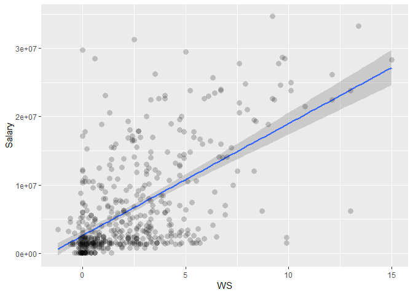

```r
  # 9
  ggplot(data=wages, aes(x=WS, y=Salary)) +
    geom_smooth(method="lm") +
    geom_point(stat="identity", alpha=0.2, size=3, shape=16)
```

# Exercise 2

Load the temparture dataset and filter the data to temperatures in Slovenia. Categorize temperature measurements into 6 bins according to the year of the measurement: 1901-1920, 1921-1940, 1941-1960, 1961-1980, 1981-2000, 2001-2015. Use a bar chart to show how temperature moved during these time intervals for each month independenlty (hint: use facet grid).

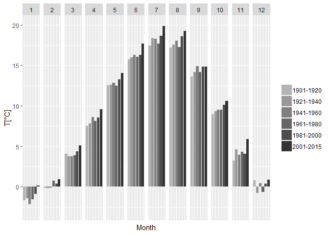

```r
  # load data
  df_temperature <- read.csv("./data/temperature.csv", na.strings="", sep=";")
  temperature <- as_tibble(df_temperature)

  # your solution here
  si_temperature <- temperature %>%
    filter(country=="Slovenia")

  # time_interval
  si_temperature$time_interval=""

  for (i in 1:nrow(si_temperature)) {
    if (si_temperature[i,]$year < 1921) {
      si_temperature[i,]$time_interval = "1901-1920"
    } else if (si_temperature[i,]$year < 1941) {
      si_temperature[i,]$time_interval = "1921-1940"
    } else if (si_temperature[i,]$year < 1961) {
      si_temperature[i,]$time_interval = "1941-1960"
    } else if (si_temperature[i,]$year < 1981) {
      si_temperature[i,]$time_interval = "1961-1980"
    } else if (si_temperature[i,]$year < 2001) {
      si_temperature[i,]$time_interval = "1981-2000"
    } else {
      si_temperature[i,]$time_interval = "2001-2015"
    }
  }

  # get averages for Slovenia
  average_temperature <- si_temperature %>%
    filter(country=="Slovenia") %>%
    group_by(time_interval,month) %>%
    summarize(temperature=mean(temperature))

  # plot
  palette <- c("grey70", "grey60", "grey50", "grey40", "grey30", "grey20")
  ggplot(data=average_temperature, aes(x=time_interval, y=temperature, fill=time_interval)) +
    geom_bar(stat="identity") +
    facet_grid(. ~ month) +
    ylim(-3, 20) +
    xlab("Month") +
    ylab("T[°C]") +
    theme(legend.title=element_blank(),
          axis.text.x=element_blank(),
          axis.ticks.x=element_blank()) +
    scale_fill_manual(values=palette)
```

# Exercise 3

Use exploratory visualizations to analyze how the knowledge of various programming languages, age and programming experience influence developer’s salary. Also explore relationships between these variables – is the number of known programming languages correlated with age, etc. Hint: You can plot each visualization independently or you can use the `cowplot` package to join multiple charts together.

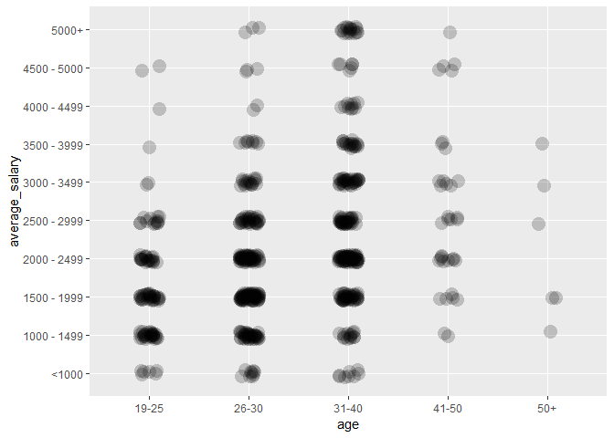

```r
  # load data
  df_salaries <- read.csv("./data/salaries.csv", na.strings="")
  salaries <- as_tibble(df_salaries)

  # your solution here
  # plots
  ggplot(data=salaries, aes(x=age, y=average_salary)) +
    geom_point(stat="identity", alpha=0.2, size=5, shape=16, position=position_jitter(width=0.1, height=0.1))
```

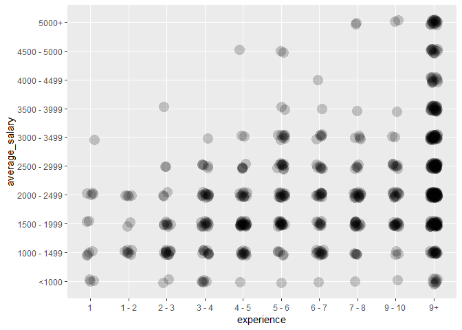

```r
  ggplot(data=salaries, aes(x=experience, y=average_salary)) +
    geom_point(stat="identity", alpha=0.2, size=5, shape=16, position=position_jitter(width=0.1, height=0.1))
```

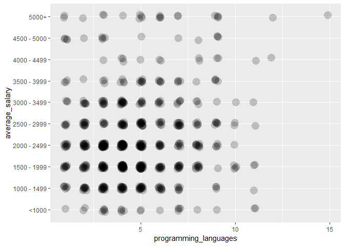

```r
  ggplot(data=salaries, aes(x=programming_languages, y=average_salary)) +
    geom_point(stat="identity", alpha=0.2, size=5, shape=16, position=position_jitter(width=0.1, height=0.1))
```

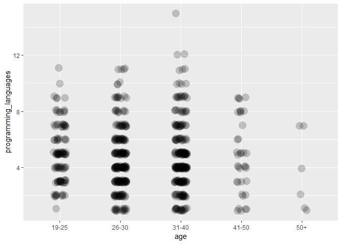

```r
  ggplot(data=salaries, aes(x=age, y=programming_languages)) +
    geom_point(stat="identity", alpha=0.2, size=5, shape=16, position=position_jitter(width=0.1, height=0.1))
```

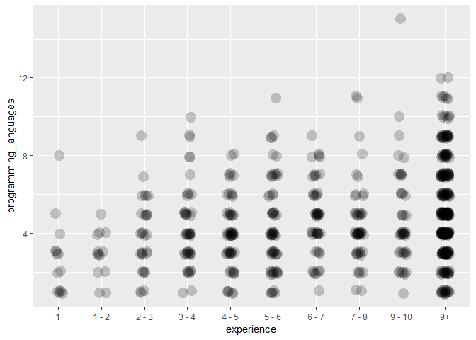

```r
  ggplot(data=salaries, aes(x=experience, y=programming_languages)) +
    geom_point(stat="identity", alpha=0.2, size=5, shape=16, position=position_jitter(width=0.1, height=0.1))
```